# Phys 386 HW 4

## (d) Use a band pass filter to isolate the low S/N signals

```python
low_ft = np.fft.fft(low_sn)
freq = np.fft.fftfreq(len(time), d=time[1]-time[0])
plt.plot(freq[:int(n_samples/2)], np.abs(low_ft)[:int(n_samples/2)])
plt.xlabel('$f$ (Hz)')
plt.ylabel('Amplitude')
plt.title('FFT of low S/N timestream')
plt.show()
```

[output not shown]

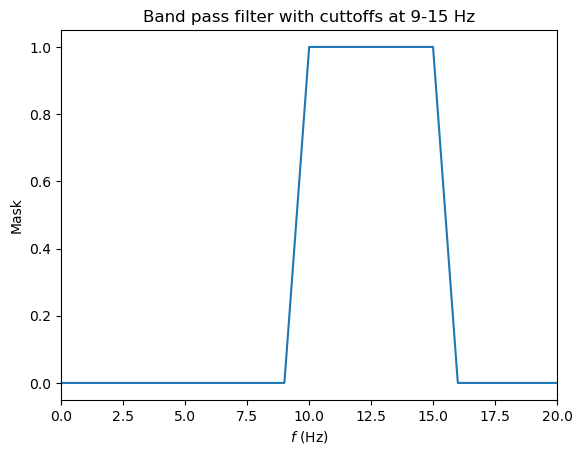

```python
# I'll do a step with cuttoffs instead of a Gaussian since I
# don't want the 0.07 period signal to disappear.
band_cutoffs = [9, 15] #  Band pass filters cuttoffs in Hz
bandpass_filter = np.where(np.abs(freq) < band_cutoffs[0], 0, 1)
bandpass_filter = np.where(np.abs(freq) > band_cutoffs[1], 0, bandpass_filter)
plt.plot(freq[:int(n_samples/2)], bandpass_filter [:int(n_samples/2)])
plt.xlabel('$f$ (Hz)')
plt.ylabel('Mask')
plt.title(f'Band pass filter with cuttoffs at {band_cutoffs[0]}-{band_cutoffs[1]} Hz')
plt.xlim(0,20)
plt.show()
```

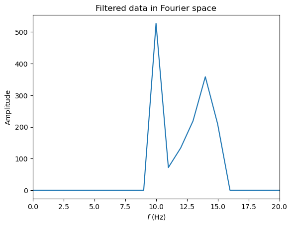

```python
bp_filtered_fft = low_ft * bandpass_filter
plt.plot(freq[:int(n_samples/2)], np.abs(bp_filtered_fft)[:int(n_samples/2)])
plt.xlabel('$f$ (Hz)')
plt.ylabel('Amplitude')
plt.title('Filtered data in Fourier space')
plt.xlim(0,20)
plt.show()
```

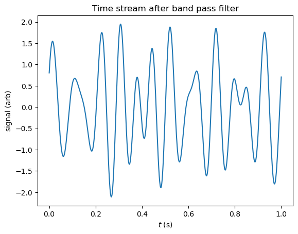

```python
low_ft_bandpass = np.fft.ifft(bp_filtered_fft)
plt.plot(time, low_ft_bandpass.real)
plt.xlabel('$t$ (s)')
plt.ylabel('signal (arb)')
plt.title('Time stream after band pass filter')
plt.show()
```

> **Comment:** It is possible to detect the low S/N signal just because we correlated it with a high S/N signal to get an estimate of the leading frequency and filter it out using the band-pass filter.

> **Other comment:** I used a rectangular band pass filter to see if I could detect the 0.07 period signal without knowing it a priori. A narrower Gaussian filter would have eliminated that extra frequency.